# 3.1 Area Under the Curve

September 24, 2015

## 3.1 Area Under the Curve

What percent of a standard normal distribution \(N(\mu = 0, \sigma = 1)\) is found in each region? Be sure to draw a graph.

1. Z < -1.35
2. Z > 1.48
3. -0.4 < Z < 1.5
4. |Z| > 2
- This question is taken from p158 of the OpenIntro Statistics (3rd Edition) book available at OpenIntro.org.

## (a) Z < -1.35

First, we define in `R` code the Z score and then use the `pnorm` function to determine the percentage on the left tail.

```r
zLt <- -1.35
pLt <- pnorm(zLt)
pLt
```

```
## [1] 0.08850799
```

## (a) Z < -1.35 Visualization

The percent of the standard normal distribution found in the region Z < -1.35 is 8.85%.

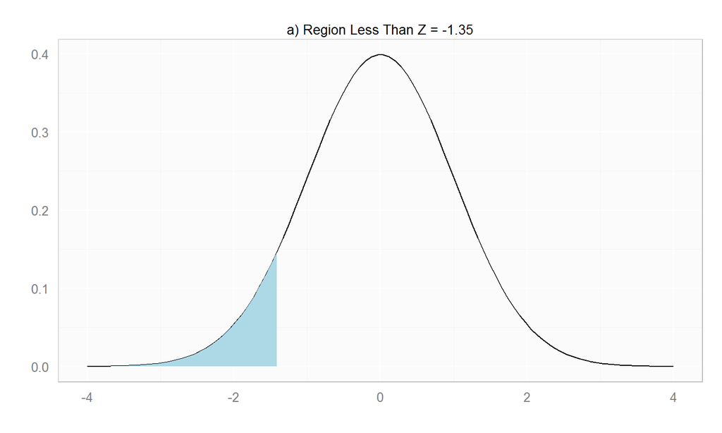

## (b) Z > 1.48

Again, we define in `R` code the Z score and then use the `pnorm` function to determine the percentage on the left tail. This time we subtract the value returned from `pnorm` from 1 to convert to the right tail value.

```r
zGt <- 1.48
pGt <- 1 - pnorm(zGt)
pGt
```

```
## [1] 0.06943662
```

## (b) Z > 1.48 Visualization

The percent of the standard normal distribution found in the region Z > 1.48 is 6.94%.

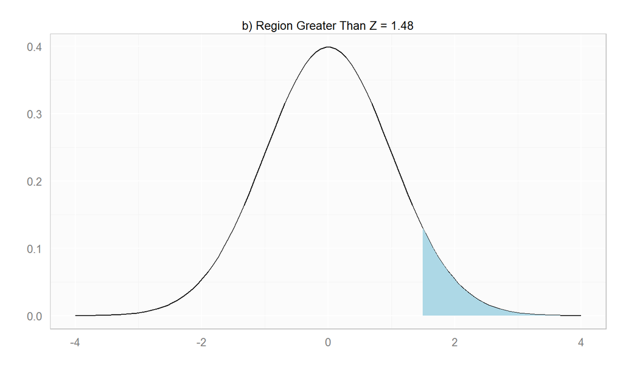

## (c) -0.4 < Z < 1.5

Again, we define in `R` code the Z scores and use `pnorm`. This time we have a middle region with a portion below zero and a portion above zero, therefore we substract using 0.5 depending on which side we are on.

```r
z1 <- -0.4
p1 <- 0.5 - pnorm(z1) # Left of mean 0

z2 <- 1.5
p2 <- pnorm(z2) - 0.5 # Right of mean 0

pT <- p1 + p2
pT
```

```
## [1] 0.5886145
```

## (c) -0.4 < Z < 1.5 Visualization

The percent of the standard normal distribution found in the region -0.4 < Z < 1.5 is 58.86%.

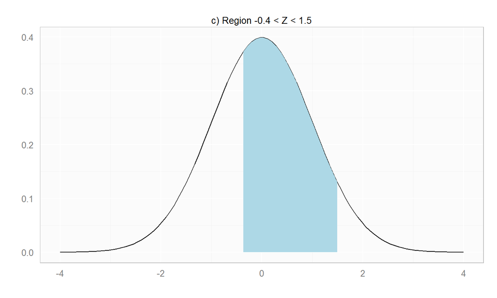

## (d) Abs(Z) > 2

Once again, we define in `R` code the Z score and use `pnorm`. We have a two separate tail regions with a portion below 0 and a portion above zero (not contiguous). In this case, the regions are identical due to the absolute value, therefore we can simply multiply by 2.

```r
z <- 2
p1 <- 1 - pnorm(z) # Right tail

pT <- 2 * p1
pT
```

```
## [1] 0.04550026
```

## (d) Abs(Z) > 2 Visualization

The percent of the standard normal distribution found in the region ( |Z| > 2) is 4.55%.

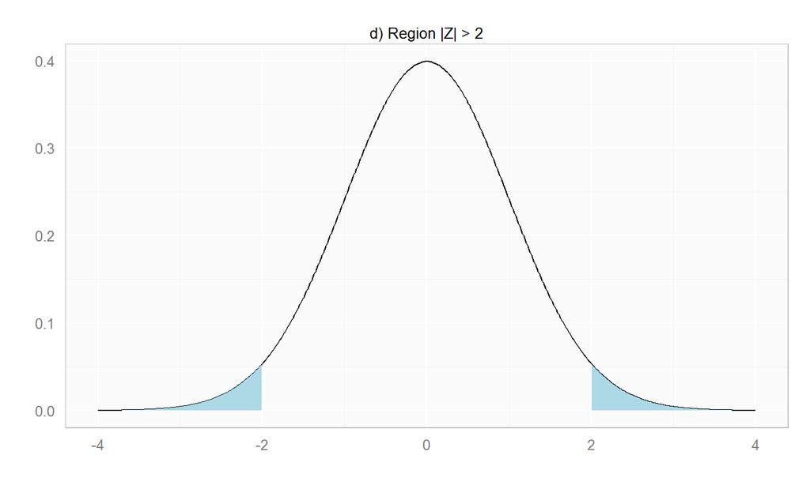